# Experimental Analysis

Julian Frattini

2025-02-26

In this Notebook, we conduct an experimental analysis. As opposed to the observational analysis, the experimental analysis allows to fully control a factor and, hence, isolate its effect on the response variable of interest.

```r
d <- read.csv(file.path(path.data.obs, 'rq4tlr-data.csv'))
```

## Factor Selection

We can only conduct an experimental analysis of a specific factor if

1. the factor is sufficiently wide distributed in the data, and
2. we can reliably manipulate the factor without requiring domain knowledge.

Only one factor in our data meets both criteria: the ratio of sentences representing clarifications (`clarification`). The factor is at least spread a little in the `iTrust` data set.

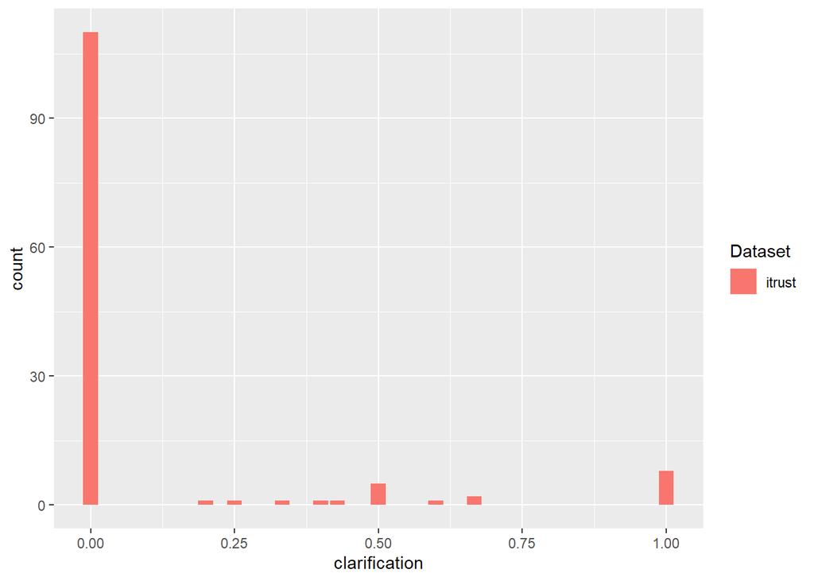

```r
d %>%
  filter(Dataset == "itrust") %>%
  ggplot(aes(x = clarification, fill = Dataset)) +
  geom_histogram(stat="count")
```

Still, a large number of use cases contained no clarification at all. The manipulation of the clarification factor will be meaningless (i.e., their level of clarification would not change when manipulating the factor). Hence, these data points are irrelevant for the experimental study. Instead, we are only interested in use cases with any clarification at all (i.e., `clarification > 0`).

```r
ucs.with.clarification <- d %>%
  filter(Dataset == "itrust" & clarification > 0)

ucs.with.clarification$File
```

```
##  [1] "UC10S2" "UC16"   "UC17S1" "UC17S2" "UC17S3" "UC18S2" "UC19S3" "UC22S1"
##  [9] "UC22S3" "UC23S3" "UC24"   "UC26S2" "UC28"   "UC29"   "UC30S6" "UC30S7"
## [17] "UC31S1" "UC32S1" "UC32S2" "UC40S2" "UC40S3"
```

## Data Preparation

Since only the iTrust data set showed any values of `clarification` worth manipulating at all, we only load the data set containing the TLR results for the iTrust data set (where all clarifications were removed).

```r
d.treatment <- read.csv(file.path(path.data.exp, 'itrustClarificationCleaned_OPT_m52f42_FTLRMcCd_perArtifactMetrics.csv'), sep=';') %>%
  mutate(Dataset = 'itrust') %>%
  rowwise() %>%
  mutate(File = strsplit(sourceID, '\\.')[[1]][1]) %>%
  select(!c(sourceID, tp, fp, fn, LAG))

d.treatment$clarification = 0.0

head(d.treatment)
```

```
## # A tibble: 6 x 7
## # Rowwise:
##   Precision Recall    F1      AP Dataset File   clarification
##       <dbl>  <dbl> <dbl>   <dbl> <chr>   <chr>          <dbl>
## 1     0      0     0     0.0177  itrust  UC10E1             0
## 2     0      0     0     0.0116  itrust  UC10E2             0
## 3     0.333  0.286 0.308 0.456   itrust  UC10S1             0
## 4     0      0     0     0.0435  itrust  UC10S2             0
## 5     0      0     0     0.0121  itrust  UC11E1             0
## 6     0      0     0     0.00912 itrust  UC11E2             0
```

The corresponding “control” data set is the original iTrust data set.

```r
d.control <- d %>%
  filter(Dataset == "itrust") %>%
  select(c(Dataset, File, clarification, Precision, Recall, F1, AP))

head(d.control)
```

```
##   Dataset   File clarification Precision    Recall        F1          AP
## 1  itrust UC10E1           0.0 0.0000000 0.0000000 0.0000000 0.017708333
## 2  itrust UC10E2           0.0 0.0000000 0.0000000 0.0000000 0.011634004
## 3  itrust UC10S1           0.0 0.3333333 0.2857143 0.3076923 0.455545970
## 4  itrust UC10S2           0.5 0.0000000 0.0000000 0.0000000 0.043478261
## 5  itrust UC11E1           0.0 0.0000000 0.0000000 0.0000000 0.012072650
## 6  itrust UC11E2           0.0 0.0000000 0.0000000 0.0000000 0.009115449
```

Then, we combine the two data sets via `rbind`. Since we reduced both data sets to the same set of columns (i.e., its identification via `Dataset` and `File`, the main independent factor `clarification`, and the four existing, dependent variables), we can just “stack them” on top of each other. At this step, we also remove all data points where the `clarification` value in the control data set was already 0.

```r
d <- rbind(d.control, d.treatment)

d <- d %>%
  filter(File %in% ucs.with.clarification$File)
```

We additionally calculate a fifth response variable: the $F_2$-score. Like the $F_1$-score, this is an operationalization of the more general $F_{\beta}$-score, but $F_2$ puts more emphasis on recall over precision.

```r
calc_f_beta <- function(beta, precision, recall) {
  f <- (1+beta^2) * ((precision * recall)/(beta^2*precision + recall))
  return(ifelse(is.nan(f), 0, f))
}

d <- d %>%
  mutate(F2 = calc_f_beta(2, Precision, Recall))
```

## Data Analysis

With the data set prepared, we can begin the data analysis.

### Distribution and Formula

The regression formula derived from our causal model (where only the `clarification` affects the response variables) can be modeled as a multivariate regression.

```r
f <- bf(mvbind(Precision, Recall, F1, F2, AP) ~ 0 + Intercept + clarification + (1|File)) + set_rescor(FALSE)
```

First, we need to select an appropriate distribution type for the response variables. Given that all response variables are bounded within $[0; 1]$, a distribution from the beta-family is appropriate.

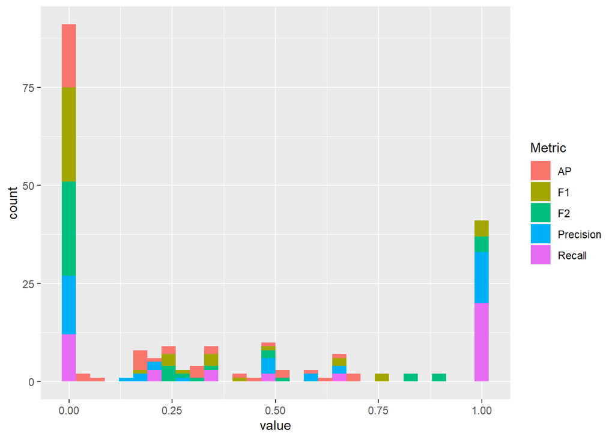

```r
d %>%
  pivot_longer(cols=c(Precision, Recall, F1, F2, AP), names_to = "Metric") %>%
  ggplot(aes(x = value, fill=Metric)) +
    geom_histogram()
```

The distribution of the response variables shows that there are several 0 and 1 values. These are typically not expected in a classical `beta` distribution. Instead, we ought to select a `zero_one_inflated_beta` distribution.

### Prior Selction and Prior Predictive Check

The `zero_one_inflated_beta` distribution requires specifying the following priors.

```r
get_prior(f, d, family=zero_one_inflated_beta)
```

```
##                 prior class          coef group      resp dpar nlpar lb ub
##                (flat)     b
##                (flat)     b                            AP
##                (flat)     b clarification              AP
##                (flat)     b     Intercept              AP
##            beta(1, 1)   coi                            AP             0  1
##     gamma(0.01, 0.01)   phi                            AP             0
##  student_t(3, 0, 2.5)    sd                            AP             0
##  student_t(3, 0, 2.5)    sd                File        AP             0
##  student_t(3, 0, 2.5)    sd     Intercept  File        AP             0
##            beta(1, 1)   zoi                            AP             0  1
##                (flat)     b                            F1
##                (flat)     b clarification              F1
##                (flat)     b     Intercept              F1
##            beta(1, 1)   coi                            F1             0  1
##     gamma(0.01, 0.01)   phi                            F1             0
##  student_t(3, 0, 2.5)    sd                            F1             0
##  student_t(3, 0, 2.5)    sd                File        F1             0
##  student_t(3, 0, 2.5)    sd     Intercept  File        F1             0
##            beta(1, 1)   zoi                            F1             0  1
##                (flat)     b                            F2
##                (flat)     b clarification              F2
##                (flat)     b     Intercept              F2
##            beta(1, 1)   coi                            F2             0  1
##     gamma(0.01, 0.01)   phi                            F2             0
##  student_t(3, 0, 2.5)    sd                            F2             0
##  student_t(3, 0, 2.5)    sd                File        F2             0
##  student_t(3, 0, 2.5)    sd     Intercept  File        F2             0
##            beta(1, 1)   zoi                            F2             0  1
##                (flat)     b                     Precision
##                (flat)     b clarification       Precision
##                (flat)     b     Intercept       Precision
##            beta(1, 1)   coi                     Precision             0  1
##     gamma(0.01, 0.01)   phi                     Precision             0
##  student_t(3, 0, 2.5)    sd                     Precision             0
##  student_t(3, 0, 2.5)    sd                File Precision             0
##  student_t(3, 0, 2.5)    sd     Intercept  File Precision             0
##            beta(1, 1)   zoi                     Precision             0  1
##                (flat)     b                        Recall
##                (flat)     b clarification          Recall
```

[output cut: 39 more lines]

```
##       default
##       default
##       default
##  (vectorized)
##  (vectorized)
##       default
##       default
##  (vectorized)
##  (vectorized)
##       default
##       default
##       default
##  (vectorized)
##  (vectorized)
##       default
```

We select uninformative priors for each factor coefficient.

```r
p1 <- c(
  prior(normal(0, 0.3), class = b, resp=Precision),
  prior(normal(0, 0.5), class = b, resp=Recall),
  prior(normal(0, 0.5), class = b, resp=F1),
  prior(normal(0, 0.5), class = b, resp=F2),
  prior(normal(0, 0.5), class = b, resp=AP),

  # phi parameter
  prior(gamma(4, 1), class = phi, resp=Precision),
  prior(gamma(4, 1), class = phi, resp=Recall),
  prior(gamma(4, 1), class = phi, resp=F1),
  prior(gamma(4, 1), class = phi, resp=F2),
  prior(gamma(4, 1), class = phi, resp=AP),

  # coi parameter
  prior(beta(5, 2), class = coi, resp=Precision),
  prior(beta(5, 2), class = coi, resp=Recall),
  prior(beta(5, 2), class = coi, resp=F1),
  prior(beta(5, 2), class = coi, resp=F2),
  prior(beta(5, 2), class = coi, resp=AP),

  # zoi parameter
  prior(beta(3, 2), class = zoi, resp=Precision),
  prior(beta(3, 2), class = zoi, resp=Recall),
  prior(beta(3, 2), class = zoi, resp=F1),
  prior(beta(3, 2), class = zoi, resp=F2),
  prior(beta(3, 2), class = zoi, resp=AP),

  # standard deviation parameter
  prior(weibull(2, 0.5), class = sd, resp=Precision),
  prior(weibull(2, 0.5), class = sd, resp=Recall),
  prior(weibull(2, 0.5), class = sd, resp=F1),
  prior(weibull(2, 0.5), class = sd, resp=F2),
  prior(weibull(2, 0.5), class = sd, resp=AP)
)
```

To confirm the eligibility of the priors, we run a prior predictive check, i.e., we sample from the specified model without updating the coefficient distributions. We achieve this via the `sample_prior="only"` flag.

```r
m1.prior <-
  brm(data = d, family = zero_one_inflated_beta, f, prior = p1,
    iter = 4000, warmup = 1000, chains = 4, cores = 4,
    seed = 4, sample_prior="only",
    file = "../fits/exp.prior"
  )
```

We can draw from this model to visually inspect the eligibility of the priors.

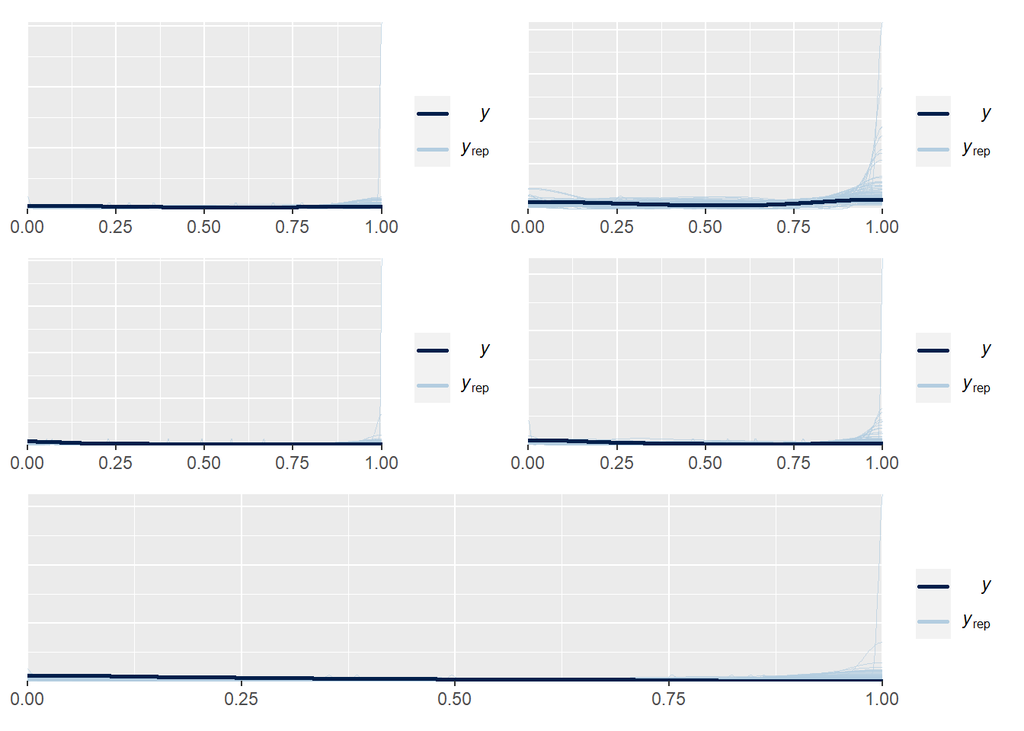

```r
prior.precision <- brms::pp_check(m1.prior, ndraws=100, resp="Precision")
prior.recall <- brms::pp_check(m1.prior, ndraws=100, resp="Recall")
prior.f1 <- brms::pp_check(m1.prior, ndraws=100, resp="F1")
prior.f2 <- brms::pp_check(m1.prior, ndraws=100, resp="F2")
prior.ap <- brms::pp_check(m1.prior, ndraws=100, resp="AP")

(prior.precision | prior.recall) / (prior.f1 | prior.f2) / prior.ap
```

The prior predictive check $y_{rep}$ overlaps with the actually observed data $y$, which confirms the eligibility of the priors.

### Model Training

With the eligibility of priors confirmed, we train the regression model, i.e., update the factor coefficient distributions given the observed data.

```r
m1 <-
  brm(data = d, family = zero_one_inflated_beta, f, prior = p1,
    iter = 4000, warmup = 1000, chains = 4, cores = 4, seed = 4,
    file = "../fits/exp"
  )
```

We can perform a similar predictive check by drawing samples from the (this time trained/updated) model.

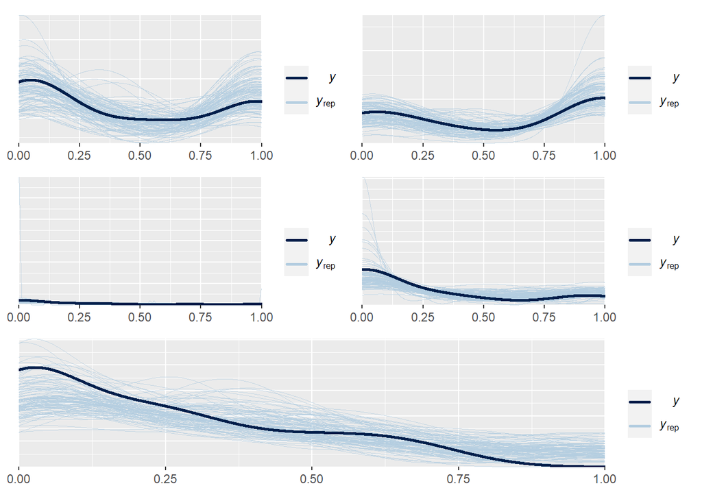

```r
posterior.precision <- brms::pp_check(m1, ndraws=100, resp="Precision")
posterior.recall <- brms::pp_check(m1, ndraws=100, resp="Recall")
posterior.f1 <- brms::pp_check(m1, ndraws=100, resp="F1")
posterior.f2 <- brms::pp_check(m1, ndraws=100, resp="F2")
posterior.ap <- brms::pp_check(m1, ndraws=100, resp="AP")

(posterior.precision | posterior.recall) / (posterior.f1 | posterior.f2) / posterior.ap
```

The predictions $y_{rep}$ have moved closer to the actually observed data $y$. This confirms that the model has trained properly and gained predictive power.

### Evaluation

Finally, we can evaluate the resulting model. The summary of path coefficients gives a raw insight into the updated model parameters.

```r
summary(m1)
```

```
##  Family: MV(zero_one_inflated_beta, zero_one_inflated_beta, zero_one_inflated_beta, zero_one_inflated_beta, zero_one_inflated_beta)
##   Links: mu = logit; phi = identity; zoi = identity; coi = identity
##          mu = logit; phi = identity; zoi = identity; coi = identity
##          mu = logit; phi = identity; zoi = identity; coi = identity
##          mu = logit; phi = identity; zoi = identity; coi = identity
##          mu = logit; phi = identity; zoi = identity; coi = identity
## Formula: Precision ~ 0 + Intercept + clarification + (1 | File)
##          Recall ~ 0 + Intercept + clarification + (1 | File)
##          F1 ~ 0 + Intercept + clarification + (1 | File)
##          F2 ~ 0 + Intercept + clarification + (1 | File)
##          AP ~ 0 + Intercept + clarification + (1 | File)
##    Data: d (Number of observations: 42)
##   Draws: 4 chains, each with iter = 4000; warmup = 1000; thin = 1;
##          total post-warmup draws = 12000
##
## Group-Level Effects:
## ~File (Number of levels: 21)
##                         Estimate Est.Error l-95% CI u-95% CI Rhat Bulk_ESS
## sd(Precision_Intercept)     0.43      0.20     0.09     0.87 1.00     6737
## sd(Recall_Intercept)        0.41      0.20     0.07     0.86 1.00     7897
## sd(F1_Intercept)            0.44      0.20     0.10     0.87 1.00     7297
## sd(F2_Intercept)            0.59      0.23     0.15     1.04 1.00     5661
## sd(AP_Intercept)            0.58      0.19     0.19     0.96 1.00     4759
##                         Tail_ESS
## sd(Precision_Intercept)     5923
## sd(Recall_Intercept)        6177
## sd(F1_Intercept)            6329
## sd(F2_Intercept)            5395
## sd(AP_Intercept)            4779
##
## Population-Level Effects:
##                         Estimate Est.Error l-95% CI u-95% CI Rhat Bulk_ESS
## Precision_Intercept        -0.18      0.20    -0.57     0.22 1.00    12731
## Precision_clarification    -0.22      0.27    -0.74     0.31 1.00    18016
## Recall_Intercept           -0.28      0.29    -0.84     0.29 1.00    12590
## Recall_clarification       -0.09      0.41    -0.89     0.72 1.00    15447
## F1_Intercept               -0.14      0.25    -0.64     0.35 1.00    11173
## F1_clarification           -0.38      0.40    -1.16     0.41 1.00    15063
## F2_Intercept                0.03      0.28    -0.53     0.57 1.00    10762
## F2_clarification           -0.26      0.41    -1.04     0.55 1.00    18251
```

[output cut: 20 more lines]

```
## phi_AP            7.29      2.33     3.64    12.64 1.00     5762     8547
## zoi_Precision     0.66      0.07     0.52     0.79 1.00    16756     8104
## zoi_Recall        0.74      0.06     0.61     0.86 1.00    20404     8545
## zoi_F1            0.66      0.07     0.52     0.79 1.00    21742     8518
## zoi_F2            0.66      0.07     0.52     0.79 1.00    21002     8947
## zoi_AP            0.41      0.07     0.27     0.55 1.00    21649     8818
## coi_Precision     0.51      0.08     0.35     0.68 1.00    25408     8623
## coi_Recall        0.64      0.08     0.49     0.78 1.00    21629     8293
## coi_F1            0.26      0.07     0.13     0.41 1.00    21060     8650
## coi_F2            0.26      0.07     0.13     0.41 1.00    23162     8346
## coi_AP            0.22      0.08     0.08     0.40 1.00    22246     7483
##
## Draws were sampled using sampling(NUTS). For each parameter, Bulk_ESS
## and Tail_ESS are effective sample size measures, and Rhat is the potential
## scale reduction factor on split chains (at convergence, Rhat = 1).
```

We can visualize the distribution of the interesting coefficients (e.g., `b_Precision_clarification`) in an errorbar plot. This shows, on which response variables the `clarification` has a significant impact.

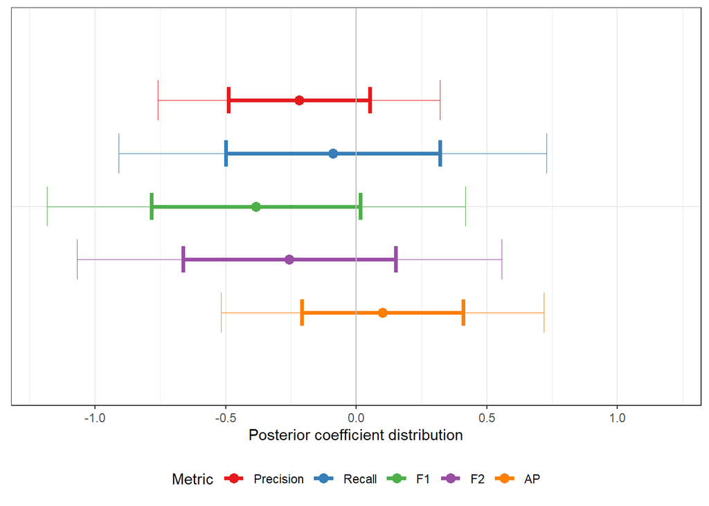

```r
dodge = 0.8 # distance between error bars of each metric

ci1.width = 0.6 # size of the whiskers of the outer confidence interval
ci2.width = 0.4 # size of the whiskers of the inner confidence interval

ci1.thic = 0.1 # thickness of the outer confidence interval
ci2.thic = 1.3 # thickness of the inner confidence interval

summary(m1)$fixed %>%
  select(Estimate, Est.Error) %>%
  rownames_to_column("coef") %>%
  filter(endsWith(coef, "clarification")) %>%
  rowwise() %>%
  mutate(coef = strsplit(coef, "_")[[1]][1]) %>%
  rename(all_of(c(
    avg = "Estimate",
    var = "Est.Error"
  ))) %>%
  mutate(coef = factor(coef, levels = c("Precision", "Recall", "F1", "F2", "AP"), ordered = TRUE)) %>%
  mutate(coef = fct_rev(coef)) %>%
  ggplot(aes(y = "a", color = coef)) +
    geom_point(aes(x = avg), position=position_dodge(width=dodge), size = 3) +
    geom_errorbar(aes(xmin = avg-2*var, xmax = avg+2*var),
                  width=ci1.width, linewidth=ci1.thic,
                  position=position_dodge(width=dodge)) +
    geom_errorbar(aes(xmin = avg-var, xmax = avg+var),
                  width=ci2.width, linewidth=ci2.thic,
                  position=position_dodge(width=dodge)) +
    geom_vline(xintercept=0, color = "grey") +
    theme_bw() +
    theme(axis.title.y=element_blank(), axis.ticks.y = element_blank(), axis.text.y = element_blank(),
          legend.position = "bottom") +
    labs(
      x = "Posterior coefficient distribution",
      color = "Metric") +
    scale_color_manual(values = brewer.pal(n = 5, name = "Set1"), limits=c("Precision", "Recall", "F1", "F2", "AP")) +
    xlim(-1.2, 1.2)
```

The results show that precision, and consequently the $F_1$-score, are affected the most. The $F_2$-score is more cautious since the recall is less affected.

```r
ggsave(
  file = file.path(path.figures, "exp-coefs-clarification.pdf"), device = "pdf",
  width = 12, height = 5, units = "cm")
```

Finally, we can also look at the marginal plots. These visualize the effect of the independent variable `clarification` on the response variables while holding all other values at a constant, representative level. This way, marginal plots incorporate all the uncertainty encoded in the trained regression model.

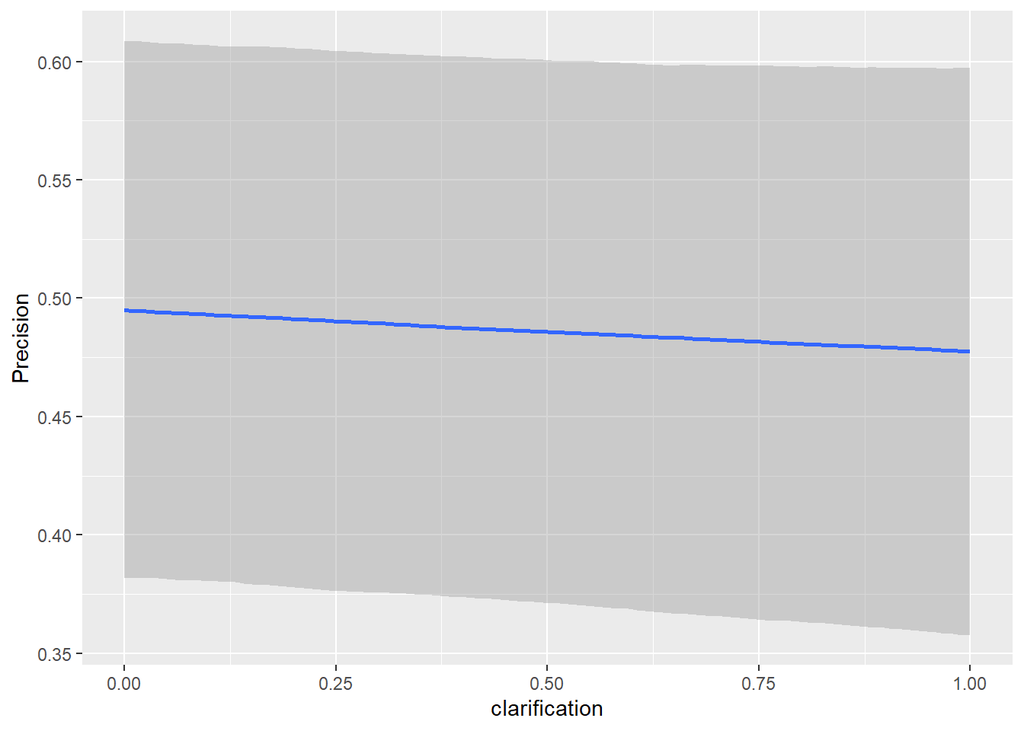

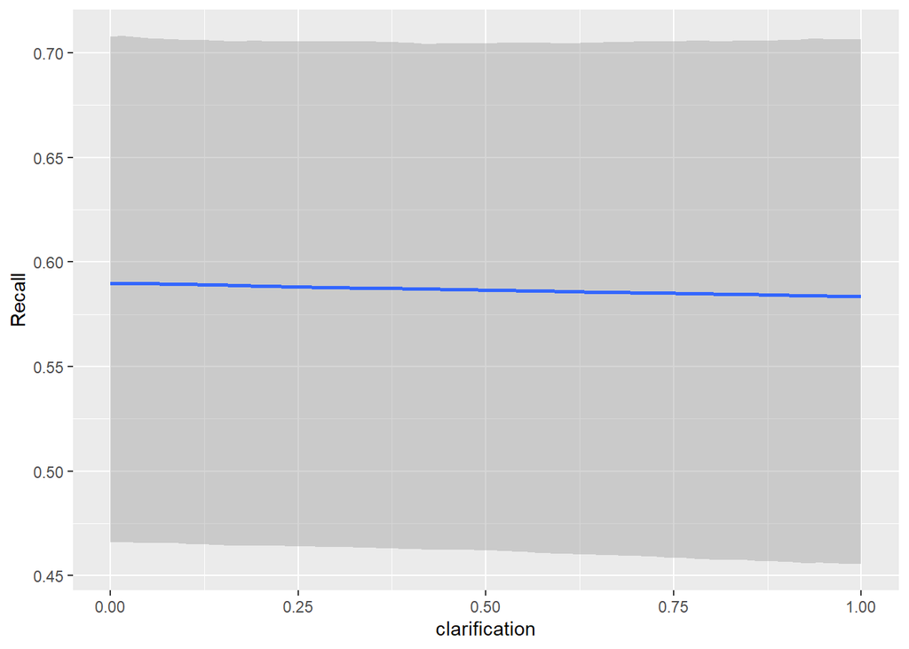

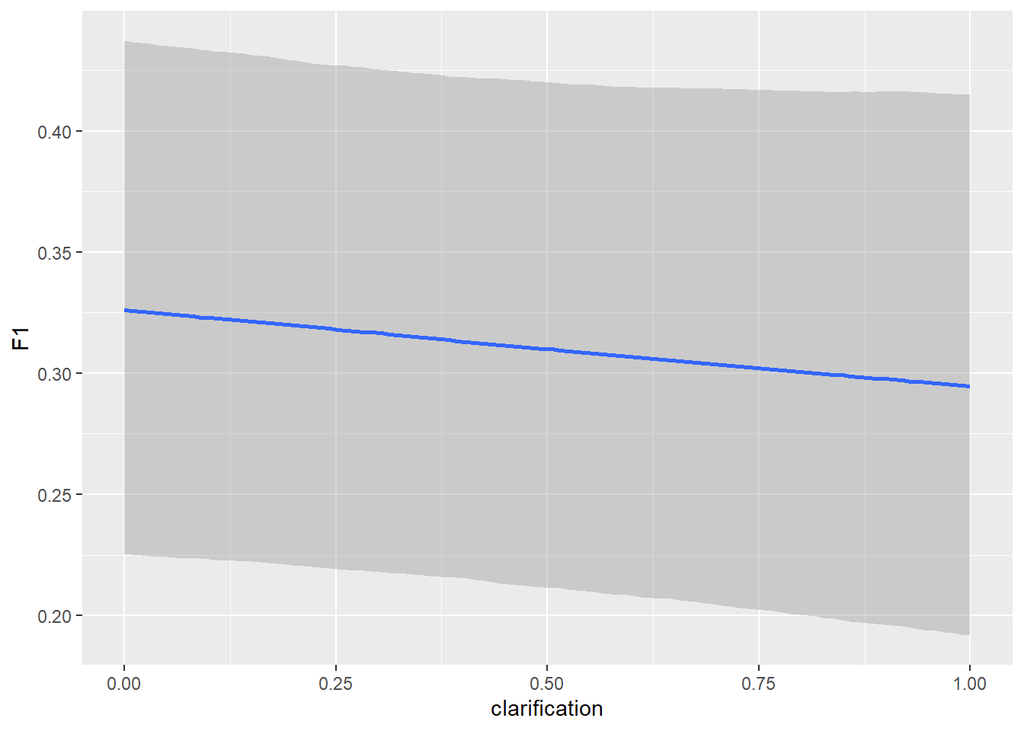

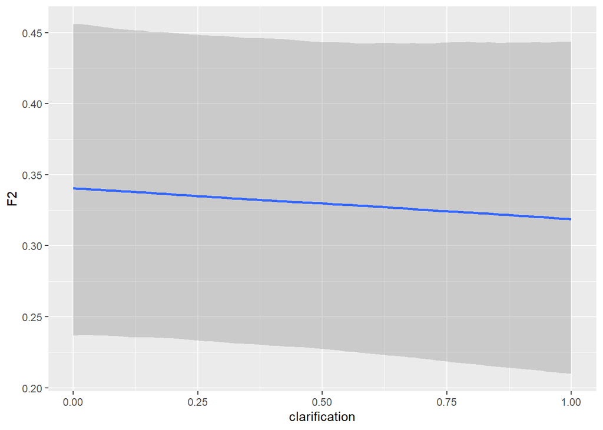

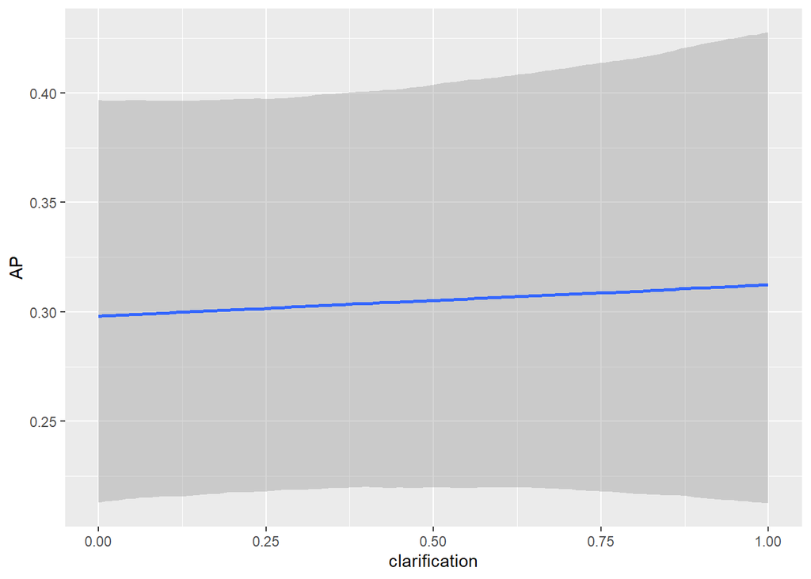

```r
conditional_effects(m1, effects="clarification", method="posterior_epred")
```

The marginal plots confirm that an increasing level of `clarification` has no strong, significant effect on any of the response variables.